# Data Preprocessing

```python
import pandas as pd
import numpy as np
import matplotlib.pyplot as plt
import seaborn as sns
import nltk
import re
from sklearn.model_selection import train_test_split
from sklearn.feature_extraction.text import TfidfVectorizer
from wordcloud import WordCloud
nltk.download('stopwords')
```

```
True
```

**Features Table**

```python
from IPython.display import Markdown

table_text = """
| Feature Name | Description |
|--------------|-------------|
| Hotel_Address | Address of hotel |
| Review_Date | Date when reviewer posted the corresponding review |
| Average_Score | Average score of the hotel, based on latest comments in the last year |
| Hotel_Name | Name of the hotel |
| Reviewer_Nationality | Nationality of the reviewer |
| Negative_Review | Negative review text. 'No Negative' if none provided |
| Review_Total_Negative_Word_Counts | Total number of words in the negative review |
| Positive_Review | Positive review text. 'No Positive' if none provided |
| Review_Total_Positive_Word_Counts | Total number of words in the positive review |
| Reviewer_Score | Score the reviewer gave based on their experience |
| Total_Number_of_Reviews_Reviewer_Has_Given | Number of reviews the reviewer has given in the past |
| Total_Number_of_Reviews | Total number of valid reviews for the hotel |
| Tags | Tags the reviewer gave to the hotel |
| days_since_review | Duration between the review date and scrape date |
| Additional_Number_of_Scoring | Number of scores given without a written review |
| lat | Latitude of the hotel |
| lng | Longitude of the hotel |
"""

Markdown(table_text)
```

| Feature Name | Description |
| --- | --- |
| Hotel_Address | Address of hotel |
| Review_Date | Date when reviewer posted the corresponding review |
| Average_Score | Average score of the hotel, based on latest comments in the last year |
| Hotel_Name | Name of the hotel |
| Reviewer_Nationality | Nationality of the reviewer |
| Negative_Review | Negative review text. 'No Negative' if none provided |
| Review_Total_Negative_Word_Counts | Total number of words in the negative review |
| Positive_Review | Positive review text. 'No Positive' if none provided |
| Review_Total_Positive_Word_Counts | Total number of words in the positive review |
| Reviewer_Score | Score the reviewer gave based on their experience |
| Total_Number_of_Reviews_Reviewer_Has_Given | Number of reviews the reviewer has given in the past |
| Total_Number_of_Reviews | Total number of valid reviews for the hotel |
| Tags | Tags the reviewer gave to the hotel |
| days_since_review | Duration between the review date and scrape date |
| Additional_Number_of_Scoring | Number of scores given without a written review |
| lat | Latitude of the hotel |
| lng | Longitude of the hotel |

```python
df = pd.read_csv('/content/Hotel_Reviews.csv')
```

```python
df.info()
```

```
<class 'pandas.core.frame.DataFrame'>
RangeIndex: 515738 entries, 0 to 515737
Data columns (total 17 columns):
 #   Column                                      Non-Null Count   Dtype
---  ------                                      --------------   -----
 0   Hotel_Address                               515738 non-null  object
 1   Additional_Number_of_Scoring                515738 non-null  int64
 2   Review_Date                                 515738 non-null  object
 3   Average_Score                               515738 non-null  float64
 4   Hotel_Name                                  515738 non-null  object
 5   Reviewer_Nationality                        515738 non-null  object
 6   Negative_Review                             515738 non-null  object
 7   Review_Total_Negative_Word_Counts           515738 non-null  int64
 8   Total_Number_of_Reviews                     515738 non-null  int64
 9   Positive_Review                             515738 non-null  object
 10  Review_Total_Positive_Word_Counts           515738 non-null  int64
 11  Total_Number_of_Reviews_Reviewer_Has_Given  515738 non-null  int64
 12  Reviewer_Score                              515738 non-null  float64
 13  Tags                                        515738 non-null  object
 14  days_since_review                           515738 non-null  object
 15  lat                                         512470 non-null  float64
 16  lng                                         512470 non-null  float64
dtypes: float64(4), int64(5), object(8)
memory usage: 66.9+ MB
```

```python
df.head(10)
```

|  | Hotel_Address | Additional_Number_of_Scoring | Review_Date | Average_Score | Hotel_Name | Reviewer_Nationality | Negative_Review | Review_Total_Negative_Word_Counts | Total_Number_of_Reviews | Positive_Review | Review_Total_Positive_Word_Counts | Total_Number_of_Reviews_Reviewer_Has_Given | Reviewer_Score | Tags | days_since_review | lat | lng |
| --- | --- | --- | --- | --- | --- | --- | --- | --- | --- | --- | --- | --- | --- | --- | --- | --- | --- |
| 0 | s Gravesandestraat 55 Oost 1092 AA Amsterdam ... | 194 | 8/3/2017 | 7.7 | Hotel Arena | Russia | I am so angry that i made this post available... | 397 | 1403 | Only the park outside of the hotel was beauti... | 11 | 7 | 2.9 | [' Leisure trip ', ' Couple ', ' Duplex Double... | 0 days | 52.360576 | 4.915968 |
| 1 | s Gravesandestraat 55 Oost 1092 AA Amsterdam ... | 194 | 8/3/2017 | 7.7 | Hotel Arena | Ireland | No Negative | 0 | 1403 | No real complaints the hotel was great great ... | 105 | 7 | 7.5 | [' Leisure trip ', ' Couple ', ' Duplex Double... | 0 days | 52.360576 | 4.915968 |
| 2 | s Gravesandestraat 55 Oost 1092 AA Amsterdam ... | 194 | 7/31/2017 | 7.7 | Hotel Arena | Australia | Rooms are nice but for elderly a bit difficul... | 42 | 1403 | Location was good and staff were ok It is cut... | 21 | 9 | 7.1 | [' Leisure trip ', ' Family with young childre... | 3 days | 52.360576 | 4.915968 |
| 3 | s Gravesandestraat 55 Oost 1092 AA Amsterdam ... | 194 | 7/31/2017 | 7.7 | Hotel Arena | United Kingdom | My room was dirty and I was afraid to walk ba... | 210 | 1403 | Great location in nice surroundings the bar a... | 26 | 1 | 3.8 | [' Leisure trip ', ' Solo traveler ', ' Duplex... | 3 days | 52.360576 | 4.915968 |
| 4 | s Gravesandestraat 55 Oost 1092 AA Amsterdam ... | 194 | 7/24/2017 | 7.7 | Hotel Arena | New Zealand | You When I booked with your company on line y... | 140 | 1403 | Amazing location and building Romantic setting | 8 | 3 | 6.7 | [' Leisure trip ', ' Couple ', ' Suite ', ' St... | 10 days | 52.360576 | 4.915968 |
| 5 | s Gravesandestraat 55 Oost 1092 AA Amsterdam ... | 194 | 7/24/2017 | 7.7 | Hotel Arena | Poland | Backyard of the hotel is total mess shouldn t... | 17 | 1403 | Good restaurant with modern design great chil... | 20 | 1 | 6.7 | [' Leisure trip ', ' Group ', ' Duplex Double ... | 10 days | 52.360576 | 4.915968 |
| 6 | s Gravesandestraat 55 Oost 1092 AA Amsterdam ... | 194 | 7/17/2017 | 7.7 | Hotel Arena | United Kingdom | Cleaner did not change our sheet and duvet ev... | 33 | 1403 | The room is spacious and bright The hotel is ... | 18 | 6 | 4.6 | [' Leisure trip ', ' Group ', ' Duplex Twin Ro... | 17 days | 52.360576 | 4.915968 |
| 7 | s Gravesandestraat 55 Oost 1092 AA Amsterdam ... | 194 | 7/17/2017 | 7.7 | Hotel Arena | United Kingdom | Apart from the price for the brekfast Everyth... | 11 | 1403 | Good location Set in a lovely park friendly s... | 19 | 1 | 10.0 | [' Leisure trip ', ' Couple ', ' Duplex Double... | 17 days | 52.360576 | 4.915968 |
| 8 | s Gravesandestraat 55 Oost 1092 AA Amsterdam ... | 194 | 7/9/2017 | 7.7 | Hotel Arena | Belgium | Even though the pictures show very clean room... | 34 | 1403 | No Positive | 0 | 3 | 6.5 | [' Leisure trip ', ' Couple ', ' Duplex Double... | 25 days | 52.360576 | 4.915968 |
| 9 | s Gravesandestraat 55 Oost 1092 AA Amsterdam ... | 194 | 7/8/2017 | 7.7 | Hotel Arena | Norway | The aircondition makes so much noise and its ... | 15 | 1403 | The room was big enough and the bed is good T... | 50 | 1 | 7.9 | [' Leisure trip ', ' Couple ', ' Large King Ro... | 26 days | 52.360576 | 4.915968 |

# Data Cleaning

```python
df['Positive_Review'] = df['Positive_Review'].replace('No Positive', '')
df['Negative_Review'] = df['Negative_Review'].replace('No Negative', '')
df['overall_review'] = df['Positive_Review'] + ' ' + df['Negative_Review']

df['days_since_review'] = df['days_since_review'].astype(str).str.extract(r'(\d+)').astype(float)
```

```python
df['overall_review'].head()
```

|  | overall_review |
| --- | --- |
| 0 | Only the park outside of the hotel was beauti... |
| 1 | No real complaints the hotel was great great ... |
| 2 | Location was good and staff were ok It is cut... |
| 3 | Great location in nice surroundings the bar a... |
| 4 | Amazing location and building Romantic settin... |

**dtype:** object

```python
print(df['overall_review'].iloc[0])
print(df['overall_review'].iloc[1])
```

```
 Only the park outside of the hotel was beautiful   I am so angry that i made this post available via all possible sites i use when planing my trips so no one will make the mistake of booking this place I made my booking via booking com We stayed for 6 nights in this hotel from 11 to 17 July Upon ar…
 No real complaints the hotel was great great location surroundings rooms amenities and service Two recommendations however firstly the staff upon check in are very confusing regarding deposit payments and the staff offer you upon checkout to refund your original payment and you can make a new one B…
```

# EDA

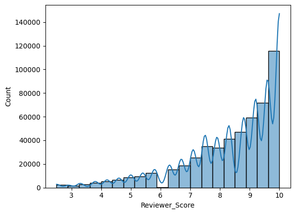

```python
sns.histplot(df['Reviewer_Score'], bins=20, kde=True)
```

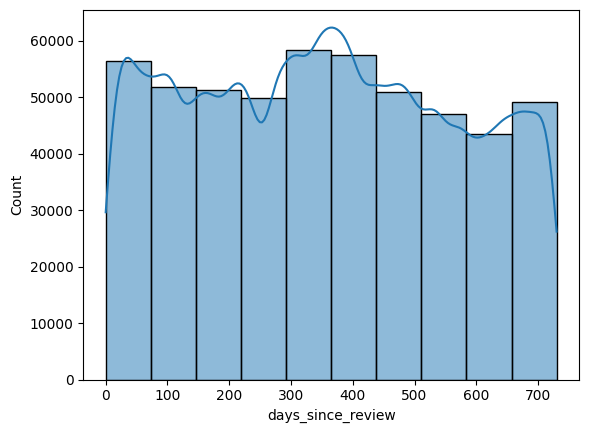

```python
#Total_Number_of_Reviews
#days_since_review

df['days_since_review']= df['days_since_review'].astype(str).str.extract('(\d+)').astype(float)

sns.histplot(df['days_since_review'], bins=10, kde=True)
```

```python
max = df['days_since_review'].max()
print(max)

min = df['days_since_review'].min()
print(min)
```

```
730.0
0.0
```

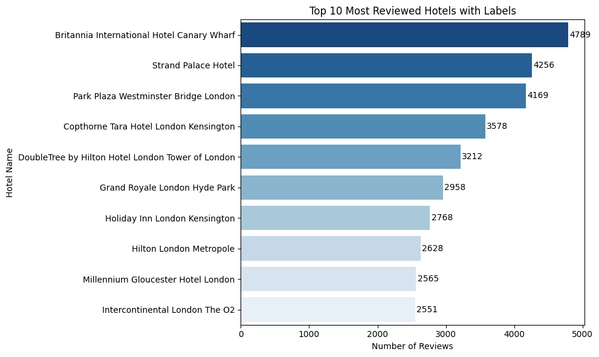

```python
top_10_hotels = df['Hotel_Name'].value_counts().head(10)

top_10_hotels = df['Hotel_Name'].value_counts().head(10)

plt.figure(figsize=(10, 6))
ax = sns.barplot(x=top_10_hotels.values, y=top_10_hotels.index, palette='Blues_r')

# 添加数值标签
for i, v in enumerate(top_10_hotels.values):
    ax.text(v + 20, i, str(v), color='black', va='center')

plt.xlabel("Number of Reviews")
plt.ylabel("Hotel Name")
plt.title("Top 10 Most Reviewed Hotels with Labels")
plt.tight_layout()
plt.show()
```

[figure not shown]

```python
# Bottom 10 hotels by avg review scores.
bottom_avg_score = df.groupby('Hotel_Name')['Average_Score'].mean().sort_values(ascending=True).head(10)

plt.figure(figsize=(12,6))
sns.barplot(x=bottom_avg_score.values, y=bottom_avg_score.index, palette='viridis')
plt.xlabel("Average Score")
plt.ylabel("Hotel Name")
plt.title("Bottom 10 Hotels by Average Review Score")

ax = plt.gca()
for i, v in enumerate(bottom_avg_score.values):
    ax.text(
        v + 0.05,
        i,
        f"{v:.2f}",
        color='black',
        va='center'
    )

plt.tight_layout()
plt.show()
```

```python
df.groupby('Reviewer_Nationality')['Reviewer_Score'].mean().sort_values(ascending=True).head(10)
```

| Reviewer_Nationality | Reviewer_Score |
| --- | --- |
| Montserrat | 5.400000 |
| American Samoa | 5.650000 |
| Northern Mariana Islands | 5.800000 |
| Mali | 6.440000 |
| Nepal | 6.840000 |
| Afghanistan | 6.875000 |
| Gabon | 7.085714 |
| Tuvalu | 7.100000 |
| Lesotho | 7.233333 |
| Mongolia | 7.251282 |

**dtype:** float64

```python
country_counts = df['Reviewer_Nationality'].value_counts().head(20)
print(country_counts)
```

```
Reviewer_Nationality
United Kingdom               245246
United States of America      35437
Australia                     21686
Ireland                       14827
United Arab Emirates          10235
Saudi Arabia                   8951
Netherlands                    8772
Switzerland                    8678
Germany                        7941
Canada                         7894
France                         7296
Israel                         6610
Italy                          6114
Belgium                        6031
Turkey                         5444
Kuwait                         4920
Spain                          4737
Romania                        4552
Russia                         3900
South Africa                   3821
Name: count, dtype: int64
```

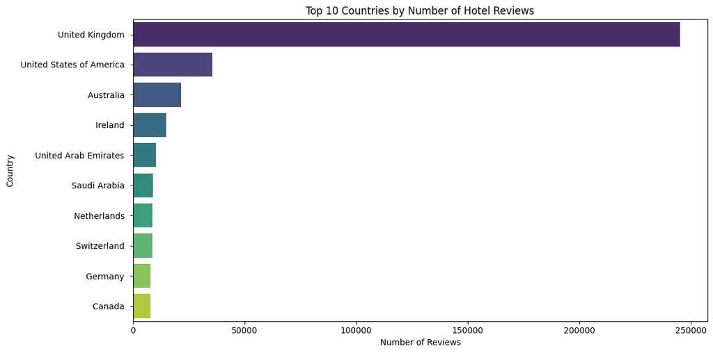

```python
import matplotlib.pyplot as plt
import seaborn as sns

plt.figure(figsize=(12,6))
sns.barplot(x=country_counts.head(10).values, y=country_counts.head(10).index, palette='viridis')
plt.title('Top 10 Countries by Number of Hotel Reviews')
plt.xlabel('Number of Reviews')
plt.ylabel('Country')
plt.tight_layout()
plt.show()
```

```python
# See how many hotel players in the datasets
unique_hotels = df['Hotel_Name'].nunique()
print(f"Number of unique hotel names: {unique_hotels}")
```

```
Number of unique hotel names: 1492
```

```python
hotel_name_counts = df['Hotel_Name'].value_counts()
print(hotel_name_counts.head(10))
```

```
Hotel_Name
Britannia International Hotel Canary Wharf           4789
Strand Palace Hotel                                  4256
Park Plaza Westminster Bridge London                 4169
Copthorne Tara Hotel London Kensington               3578
DoubleTree by Hilton Hotel London Tower of London    3212
Grand Royale London Hyde Park                        2958
Holiday Inn London Kensington                        2768
Hilton London Metropole                              2628
Millennium Gloucester Hotel London                   2565
Intercontinental London The O2                       2551
Name: count, dtype: int64
```

# Review Sentiment Classification

```python
# 1. classify reviewer score, categorized as 1(positive) if greater than 8 otherwise as 0 (negative)
df['sentiment_label'] = df['Reviewer_Score'].apply(lambda x: 1 if x >= 8 else 0)

# 2. TF-IDF
from sklearn.feature_extraction.text import TfidfVectorizer
df['overall_review'] = df['overall_review'].astype(str)

text_data = df['overall_review']
tfidf = TfidfVectorizer(max_features=5000, stop_words='english')
X = tfidf.fit_transform(text_data)

# 3. Label column
y = df['sentiment_label']
```

```python
from sklearn.model_selection import train_test_split

X_train, X_test, y_train, y_test = train_test_split(
    X, y, test_size=0.2, random_state=42)
```

```python
from sklearn.linear_model import LogisticRegression

model = LogisticRegression(max_iter=1000)
model.fit(X_train, y_train)

y_pred = model.predict(X_test)
```

```
              precision    recall  f1-score   support

           0       0.74      0.63      0.68     36165
           1       0.81      0.88      0.85     66983

    accuracy                           0.79    103148
   macro avg       0.78      0.75      0.76    103148
weighted avg       0.79      0.79      0.79    103148
```

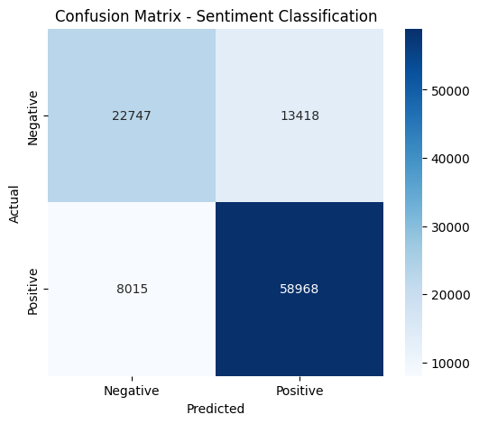

```python
from sklearn.metrics import classification_report, confusion_matrix
import seaborn as sns
import matplotlib.pyplot as plt

# print classification report
print(classification_report(y_test, y_pred))

# confusion matrix display
cm = confusion_matrix(y_test, y_pred)

plt.figure(figsize=(6,5))
sns.heatmap(cm, annot=True, fmt='d', cmap='Blues', xticklabels=['Negative', 'Positive'], yticklabels=['Negative', 'Positive'])
plt.xlabel("Predicted")
plt.ylabel("Actual")
plt.title("Confusion Matrix - Sentiment Classification")
plt.show()
```

```python
#  0   Hotel_Address                               515738 non-null  object
#  1   Additional_Number_of_Scoring                515738 non-null  int64
#  2   Review_Date                                 515738 non-null  object
#  3   Average_Score                               515738 non-null  float64
#  4   Hotel_Name                                  515738 non-null  object
#  5   Reviewer_Nationality                        515738 non-null  object
#  6   Negative_Review                             515738 non-null  object
#  7   Review_Total_Negative_Word_Counts           515738 non-null  int64
#  8   Total_Number_of_Reviews                     515738 non-null  int64
#  9   Positive_Review                             515738 non-null  object
#  10  Review_Total_Positive_Word_Counts           515738 non-null  int64
#  11  Total_Number_of_Reviews_Reviewer_Has_Given  515738 non-null  int64
#  12  Reviewer_Score                              515738 non-null  float64
#  13  Tags                                        515738 non-null  object
#  14  days_since_review                           515738 non-null  object
#  15  lat                                         512470 non-null  float64
#  16  lng                                         512470 non-null  float64
```

# Data Modeling - Rating Prediction

It is not only predicticting or guess a "score", For example, which could be used for quantifying customers' satisfaction even without given particular review_score. Also like in business practice, Airbnb campany can leverage such method to assess whether overall review_socre is inflated for hosts based on corresponding predicted scores from its' guests' feedbacks.

## Random Forest

```python
import pandas as pd
import numpy as np
from sklearn.model_selection import train_test_split
from sklearn.pipeline import Pipeline
from sklearn.compose import ColumnTransformer
from sklearn.preprocessing import OneHotEncoder
from sklearn.feature_extraction.text import TfidfVectorizer
from sklearn.ensemble import RandomForestRegressor
from sklearn.metrics import mean_absolute_error, mean_squared_error

# Random sampling n=20000
df = pd.read_csv("Hotel_Reviews.csv").sample(n=20000, random_state=42).reset_index(drop=True)

# overall_review
if 'overall_review' not in df.columns:
    pos = df['Positive_Review'].replace('No Positive', '').fillna('')
    neg = df['Negative_Review'].replace('No Negative', '').fillna('')
    df['overall_review'] = (pos.astype(str) + ' ' + neg.astype(str)).str.strip()

# make sure days_since_review as float type
if df['days_since_review'].dtype != 'float':
    df['days_since_review'] = df['days_since_review'].astype(str).str.extract(r'(\d+)').astype(float)

# Identify features and target
features = [
    'Review_Total_Positive_Word_Counts',
    'Review_Total_Negative_Word_Counts',
    'Total_Number_of_Reviews',
    'Total_Number_of_Reviews_Reviewer_Has_Given',
    'Reviewer_Nationality',
    'Tags',
    'Hotel_Name',
    'days_since_review',
    'overall_review'
]
target = 'Reviewer_Score'

# Drop NA records
df = df.dropna(subset=[target])
X = df[features]
y = df[target]

# Classify categorical and numerical features
categorical_features = ['Reviewer_Nationality', 'Tags', 'Hotel_Name']
numerical_features = [
    'Review_Total_Positive_Word_Counts',
    'Review_Total_Negative_Word_Counts',
    'Total_Number_of_Reviews',
    'Total_Number_of_Reviews_Reviewer_Has_Given',
    'days_since_review'
]
```

```python
# Preprocess step
preprocessor = ColumnTransformer(
    transformers=[
        ('text', TfidfVectorizer(max_features=5000, stop_words='english'), 'overall_review'),
        ('cat', OneHotEncoder(handle_unknown='ignore'), categorical_features),
        ('num', 'passthrough', numerical_features)
    ],
    remainder='drop'  # 显式列完了，就把其余列丢掉，避免脏列混进来
)

# Build pipeline for stremline the process
pipeline = Pipeline(steps=[
    ('preprocessing', preprocessor),
    ('regressor', RandomForestRegressor(n_estimators=100, random_state=42))
])

# Split test and train datasets
X_train, X_test, y_train, y_test = train_test_split(X, y, test_size=0.2, random_state=42)
pipeline.fit(X_train, y_train)

# Evaluate the result
y_pred = pipeline.predict(X_test)
mae = mean_absolute_error(y_test, y_pred)

# Calculate RMSE by taking the square root of MSE
rmse = mean_squared_error(y_test, y_pred) # Removed squared=False
rmse = np.sqrt(rmse) # Take the square root to get RMSE

print(f"MAE: {mae:.3f} | RMSE: {rmse:.3f}")
```

```
MAE: 0.901 | RMSE: 1.239
```

```python
# Model testing in one set of new data

from os import pipe
import pandas as pd
import string

positive_review = "The hotel was clean and the staff were friendly, great location near the metro."
negative_review = "No Negative"

# Remove punctuation and count only alphabetic words
def word_count(text):
    text = text.translate(str.maketrans('', '', string.punctuation))
    words = [w for w in text.split() if w.isalpha()]
    return len(words)

# Count pos and neg
pos_count = 0 if positive_review.strip() == "No Positive" else word_count(positive_review)
neg_count = 0 if negative_review.strip() == "No Negative" else word_count(negative_review)

print("Positive Word Count:", pos_count)
print("Negative Word Count:", neg_count)

# Create a DataFrame
new_data = pd.DataFrame([{
    'overall_review': positive_review + " " + negative_review if negative_review != "No Negative" else positive_review,
    'Reviewer_Nationality': "United Kingdom",
    'Tags': "Leisure trip; Couple; Stayed 2 nights",
    'Hotel_Name': "Hotel ABC",
    'Review_Total_Positive_Word_Counts': pos_count,
    'Review_Total_Negative_Word_Counts': neg_count,
    'Total_Number_of_Reviews': 2850,
    'Total_Number_of_Reviews_Reviewer_Has_Given': 7,
    'days_since_review': 45.0
}])

pipeline.predict(new_data)
print(f"Predicted Rating: {pred[0]:.2f}")
```

[output not shown]

## XGBoost & Gradient Boost

```python
%pip install xgboost
```

```python
from sklearn.ensemble import GradientBoostingRegressor
from xgboost import XGBRegressor
```

```python
# Compared with GBR and XGB model
models = {
    "GradientBoosting": GradientBoostingRegressor(random_state=42),
    "XGBoost": XGBRegressor(n_estimators=200, learning_rate=0.1, random_state=42, n_jobs=-1)
}

results = []
X_train, X_test, y_train, y_test = train_test_split(X, y, test_size=0.2, random_state=42)

for name, model in models.items():
    pipeline = Pipeline(steps=[
        ('preprocessing', preprocessor),
        ('regressor', model)
    ])
    pipeline.fit(X_train, y_train)
    y_pred = pipeline.predict(X_test)
    mae = mean_absolute_error(y_test, y_pred)
    rmse = np.sqrt(mean_squared_error(y_test, y_pred))
    results.append({"Model": name, "MAE": round(mae, 3), "RMSE": round(rmse, 3)})

results_df = pd.DataFrame(results)
print(results_df)
```

```
              Model    MAE   RMSE
0  GradientBoosting  0.920  1.203
1           XGBoost  0.883  1.172
```

In this rating prediction task, XGBoost achieved the best performance (MAE = 0.883, RMSE = 1.172), outperforming both Random Forest (MAE = 0.901, RMSE = 1.239) and Gradient Boosting (MAE = 0.920, RMSE = 1.203). The results suggest that XGBoost captures complex feature interactions more effectively, leading to lower overall and extreme prediction errors, while RF and GBR still provided competitive baselines.

# Topic Modeling

To understand which aspects customers prioritize—such as location convenience, hotel decor, and other factors—I will perform topic modeling on the overall review texts. By combining this with word cloud visualizations, I aim to compare the results from both LDA and BERTopic methods to analyze topic differences and determine which approach produces more meaningful insights.

```python
pip install pandas gensim nltk wordcloud matplotlib
```

## LDA

```python
import pandas as pd
import gensim
from gensim import corpora
from gensim.models.ldamulticore import LdaMulticore
from gensim.models.coherencemodel import CoherenceModel
from sklearn.feature_extraction.text import ENGLISH_STOP_WORDS
from nltk.corpus import stopwords
import nltk, string
```

```python
nltk.download('stopwords')

# 0) Load original dataset
df = pd.read_csv("Hotel_Reviews.csv")

# 1) Build overall_review only if missing
if 'overall_review' not in df.columns:
    pos = df.get('Positive_Review', '').replace('No Positive','').fillna('')
    neg = df.get('Negative_Review', '').replace('No Negative','').fillna('')
    df['overall_review'] = (pos + ' ' + neg).str.strip()

# 2) Fast text prep
STOP = set(stopwords.words('english')).union(ENGLISH_STOP_WORDS)
PUNCT = str.maketrans('', '', string.punctuation)
tokens = (
    df['overall_review'].fillna('')
      .str.lower().str.translate(PUNCT).str.split()
      .apply(lambda xs: [w for w in xs if w.isalpha() and len(w) > 2 and w not in STOP])
)
tokens = tokens[tokens.map(len) > 0].reset_index(drop=True)

# 3) Dictionary/corpus with extremes filtering
dictionary = corpora.Dictionary(tokens)
dictionary.filter_extremes(no_below=10, no_above=0.5, keep_n=100_000)
corpus = [dictionary.doc2bow(t) for t in tokens]

# 4) Train LDA (multicore)
num_topics = 10
lda = LdaMulticore(
    corpus=corpus, id2word=dictionary, num_topics=num_topics,
    chunksize=4096, iterations=100, passes=1,
    alpha='asymmetric', eta='auto', random_state=42, workers=4
)
```

```python
print("\n🎯 Top LDA Topics:")
for tid, topic in lda.show_topics(num_topics=num_topics, num_words=8, formatted=False):
    words = [w for w, _ in topic]
    print(f"Topic {tid+1}: {', '.join(words)}")
```

```
🎯 Top LDA Topics:
Topic 1: location, staff, great, hotel, good, room, breakfast, friendly
Topic 2: hotel, room, location, station, good, close, walk, metro
Topic 3: room, hotel, small, bathroom, location, bed, staff, good
Topic 4: hotel, parking, room, booking, breakfast, pool, pay, car
Topic 5: hotel, room, check, breakfast, staff, bar, time, early
Topic 6: breakfast, bed, room, comfortable, staff, good, comfy, beds
Topic 7: room, view, floor, location, shower, good, bed, staff
Topic 8: staff, helpful, friendly, excellent, location, hotel, stay, breakfast
Topic 9: room, breakfast, coffee, good, tea, nice, bar, bathroom
Topic 10: staff, hotel, reception, room, rooms, like, service, night
```

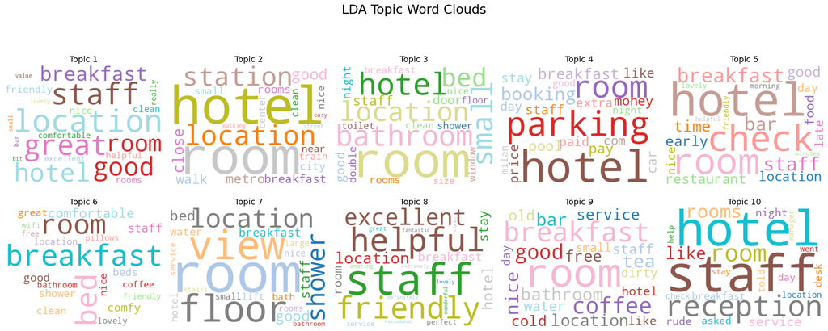

```python
from wordcloud import WordCloud
import matplotlib.pyplot as plt

# Set topics number
num_topics = 10
cols = 5
rows = (num_topics + cols - 1) // cols  # 自动计算行数

# Subplot
fig, axes = plt.subplots(rows, cols, figsize=(20, 8))
fig.suptitle("LDA Topic Word Clouds", fontsize=22, y=1.05)

# Iterate each word cloud
for i in range(num_topics):
    top_words = lda.show_topic(topicid=i, topn=20)
    word_freq = {word: weight for word, weight in top_words}

    wordcloud = WordCloud(
        width=400, height=300,
        background_color='white',
        colormap='tab20',
        random_state=i * 11
    ).generate_from_frequencies(word_freq)

    row, col = divmod(i, cols)
    ax = axes[row, col] if rows > 1 else axes[col]
    ax.imshow(wordcloud, interpolation='bilinear')
    ax.axis('off')
    ax.set_title(f"Topic {i+1}", fontsize=14)

for j in range(i+1, rows * cols):
    fig.delaxes(axes.flatten()[j])

plt.tight_layout()
plt.show()
```

For the LDA topic modeling output, we can reasonably speculate the underlying meaning of each topic based on the associated keywords. It’s important to note that the topic numbers do not imply any particular ranking or importance—they are simply labels assigned by the model.

```
1.	Location & Staff Service
2.	Transport Convenience
3.	Room Size & Facilities
4.	Parking & Amenities
5.	Check-in & Dining
6.	Comfort & Beds
7.	Scenic View & Bathroom
8.	Staff Friendliness
9.	Breakfast & Beverages
10.	Reception & Hospitality
```

```python
from collections import Counter

# Get each review's topic
dominant_topics = [
    max(lda.get_document_topics(bow), key=lambda x: x[1])[0]
    for bow in corpus
]

# Calculate the number of occurance for each topic
topic_counts = Counter(dominant_topics)

# Print distribution of topics based on topic counts
print("📊 Topic Document Distribution:")
for topic_id, count in topic_counts.most_common():
    print(f"🟦 Topic {topic_id+1}: {count} documents")
```

```
📊 Topic Document Distribution:
🟦 Topic 1: 138157 documents
🟦 Topic 2: 68189 documents
🟦 Topic 8: 66222 documents
🟦 Topic 3: 59020 documents
🟦 Topic 6: 54000 documents
🟦 Topic 9: 28965 documents
🟦 Topic 5: 27010 documents
🟦 Topic 10: 25888 documents
🟦 Topic 4: 24756 documents
🟦 Topic 7: 19827 documents
```

To determine which topics dominate overall guest feedback, I calculated the frequency of each topic as the dominant one across all reviews. The results show that Topic 1 is the most prevalent, appearing in 138,157 documents, which suggests that guests prioritize location, staff, and overall experience the most. This is followed by Topic 2, related to accessibility and transportation, and Topic 8, which covers staff service and helpfulness.

Interestingly, this output differs from my initial assumption that room facilities or comfort would take the top spot. Instead, the findings indicate that location and service quality play the most crucial roles in shaping the overall guest experience. This insight can be highly valuable for hotel industry stakeholders when conducting market research or customer analysis, especially when planning to enter a competitive market.

## BERTopic

```python
!pip install bertopic sentence-transformers hdbscan umap-learn

import pandas as pd
import numpy as np
from bertopic import BERTopic
from sklearn.feature_extraction.text import CountVectorizer
from collections import Counter
import matplotlib.pyplot as plt
```

[output not shown]

[output cut: 13 more lines]

[output not shown]

```python
df = pd.read_csv("Hotel_Reviews.csv")
if 'overall_review' not in df.columns:
    pos = df.get('Positive_Review', '').replace('No Positive', '').fillna('')
    neg = df.get('Negative_Review', '').replace('No Negative', '').fillna('')
    df['overall_review'] = (pos.astype(str) + ' ' + neg.astype(str)).str.strip()

# take sample from dataset
sample_n = 20_000
if sample_n is not None and len(df) > sample_n:
    df = df.sample(n=sample_n, random_state=42).reset_index(drop=True)

docs = df['overall_review'].fillna('').astype(str).tolist()

# Vectorizer
vectorizer_model = CountVectorizer(
    stop_words="english",
    min_df=10,
    max_df=0.5
)

# BERTopic
topic_model = BERTopic(
    vectorizer_model=vectorizer_model,
    language="english",
    calculate_probabilities=False,
    verbose=True,
)

topics, probs = topic_model.fit_transform(docs)

# Print topics info
topic_info = topic_model.get_topic_info()
print("\nTop topics overview:")
print(topic_info.head(12))
```

```
2025-08-09 19:30:44,929 - BERTopic - Embedding - Transforming documents to embeddings.
```

```
README.md: 0.00B [00:00, ?B/s]
```

```
vocab.txt: 0.00B [00:00, ?B/s]
```

```
tokenizer.json: 0.00B [00:00, ?B/s]
```

```
2025-08-09 19:36:42,702 - BERTopic - Embedding - Completed ✓
2025-08-09 19:36:42,705 - BERTopic - Dimensionality - Fitting the dimensionality reduction algorithm
2025-08-09 19:37:31,190 - BERTopic - Dimensionality - Completed ✓
2025-08-09 19:37:31,192 - BERTopic - Cluster - Start clustering the reduced embeddings
2025-08-09 19:38:10,480 - BERTopic - Cluster - Completed ✓
2025-08-09 19:38:10,494 - BERTopic - Representation - Fine-tuning topics using representation models.
2025-08-09 19:38:11,159 - BERTopic - Representation - Completed ✓
```

```
Top topics overview:
    Topic  Count                                 Name  \
0      -1   9376             -1_bathroom_bed_bar_food
1       0    634                0_wifi_wi_fi_internet
2       1    517  1_welcoming_thank_help_professional
3       2    458              2_noise_noisy_hear_loud
4       3    402          3_london_central_tower_tube
5       4    364    4_place_staffs_friendliness_value
6       5    336     5_buffet_choices_eggs_breakfasts
7       6    306               6_noisy_size_tiny_poor
8       7    258            7_beds_bed_mattress_comfy
9       8    245           8_bed_comfy_beds_selection
10      9    242           9_paris_eiffel_tower_metro
11     10    197       10_love_best_stayed_definitely

```

[output cut: 27 more lines]

```
Top 10 topics by document count (showing top-10 words each):
Topic 0 (634 docs): wifi, wi, fi, internet, connection, free, slow, poor, fast, working
Topic 1 (517 docs): welcoming, thank, help, professional, helpfull, trouble, polite, home, accommodating, super
Topic 2 (458 docs): noise, noisy, hear, loud, sound, sleep, street, outside, quiet, heard
Topic 3 (402 docs): london, central, tower, tube, bridge, garden, easy, walk, best, hotels
Topic 4 (364 docs): place, staffs, friendliness, value, attractions, main, distance, money, super, willing
Topic 5 (336 docs): buffet, choices, eggs, breakfasts, eat, expensive, included, cost, cooked, selection
Topic 6 (306 docs): noisy, size, tiny, poor, eggs, included, bathroom, fresh, bad, delicious
Topic 7 (258 docs): beds, bed, mattress, comfy, hard, double, uncomfortable, soft, super, single
Topic 8 (245 docs): bed, comfy, beds, selection, soft, cooked, mattress, hard, food, expensive
Topic 9 (242 docs): paris, eiffel, tower, metro, located, walking, wonderful, best, staying, walk
```

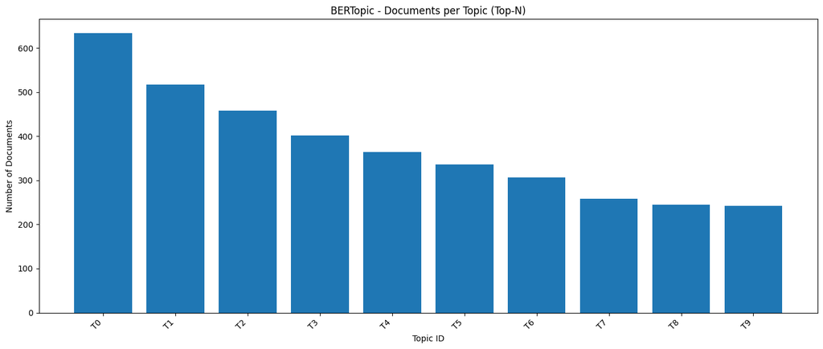

|  | Topic | Document_Count | Top_Words |
| --- | --- | --- | --- |
| 0 | 0 | 634 | wifi, wi, fi, internet, connection, free, slow... |
| 1 | 1 | 517 | welcoming, thank, help, professional, helpfull... |
| 2 | 2 | 458 | noise, noisy, hear, loud, sound, sleep, street... |
| 3 | 3 | 402 | london, central, tower, tube, bridge, garden, ... |
| 4 | 4 | 364 | place, staffs, friendliness, value, attraction... |
| 5 | 5 | 336 | buffet, choices, eggs, breakfasts, eat, expens... |
| 6 | 6 | 306 | noisy, size, tiny, poor, eggs, included, bathr... |
| 7 | 7 | 258 | beds, bed, mattress, comfy, hard, double, unco... |
| 8 | 8 | 245 | bed, comfy, beds, selection, soft, cooked, mat... |
| 9 | 9 | 242 | paris, eiffel, tower, metro, located, walking,... |

```python
from collections import Counter
import matplotlib.pyplot as plt
import pandas as pd

# Count documents per topic (excluding -1 for outliers)
valid_topics = [t for t in topics if t != -1]
counts = Counter(valid_topics)
sorted_items = sorted(counts.items(), key=lambda x: x[1], reverse=True)

TOP_N = 10         # Number of top topics to display
TOP_K_WORDS = 10    # Number of top words to show per topic

top_topic_ids = [tid for tid, _ in sorted_items[:TOP_N]]
top_topic_counts = [cnt for _, cnt in sorted_items[:TOP_N]]

# Print top-N topics with their top-K words
print(f"\nTop {TOP_N} topics by document count (showing top-{TOP_K_WORDS} words each):")
for tid in top_topic_ids:
    words = [w for w, _ in topic_model.get_topic(tid)[:TOP_K_WORDS]]
    print(f"Topic {tid} ({counts[tid]} docs): {', '.join(words)}")

# Plot: Document count per topic
labels = [f"T{tid}" for tid in top_topic_ids]
plt.figure(figsize=(14, 6))
plt.bar(labels, top_topic_counts)
plt.title("BERTopic - Documents per Topic (Top-N)")
plt.xlabel("Topic ID")
plt.ylabel("Number of Documents")
plt.xticks(rotation=45, ha='right')
plt.tight_layout()
plt.show()

# Create table for easier comparison
rows = []
for tid in top_topic_ids:
    words = [w for w, _ in topic_model.get_topic(tid)[:TOP_K_WORDS]]
    rows.append({
        "Topic": tid,
        "Document_Count": counts[tid],
        "Top_Words": ", ".join(words)
    })

topic_table = pd.DataFrame(rows).sort_values("Document_Count", ascending=False).reset_index(drop=True)
topic_table.head(TOP_N)
```

**BERTopic vs LDA**

Using BERTopic on the sampled dataset, we surfaced several distinct, action‑oriented themes. The largest topic (T0) focuses on Wi‑Fi/connectivity (wifi, internet, connection, slow/fast), followed by (T1) welcoming/helpful staff (polite, helpful, accommodating), (T2) noise disturbances (noisy, loud, street, sleep), and (T3) London‑centric location/access (central, tube, bridge, walk). Additional clusters highlight (T4) location value & staff friendliness near attractions, (T5) breakfast buffet/choice & cost, (T6) small rooms/bathroom issues, (T7–T8) bed/mattress comfort (hard vs. comfy), and (T9) Paris‑centric location/access (Eiffel, metro, walking).

Compared with LDA’s broader themes (location, staff, room, breakfast), BERTopic yields finer granularity and city‑specific clusters (e.g., London vs. Paris), and isolates operational pain points like Wi‑Fi speed and street noise. This makes it easier to target fixes (network upgrades, soundproofing, breakfast mix, bedding) and tailor market messaging by city.